# Ex23 pllet

PIE2

Tardor 2019-2020

### Per estudiar com evoluciona la quantitat de llet diària produïda per una vaca en funció dels dies que han passat des del part, s’han obtingut les dades del fitxer “pllet.csv”, en el que la primera columna són els dies i la segona la producció en l/dia.

*Directori de treball, dades, paquets del R i descriptiva*

```r
#setwd("")
library(car)
dd <- read.csv2("../data/pllet.csv")
nd<-dim(dd)[1]
head(dd)
```

```
##   DIES PROD
## 1    3 23.7
## 2   10 28.5
## 3   17 30.9
## 4   24 30.6
## 5   31 33.2
## 6   38 30.4
```

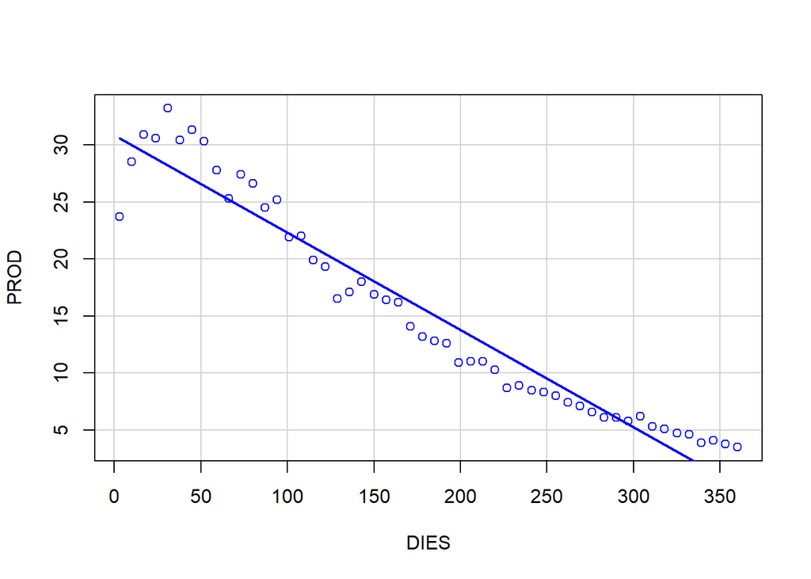

```r
################################################################
# Descriptiva
sp(PROD~DIES,boxplot=F,smooth=F,dd)
```

**Quan es necessiti utilitzeu =0.05.**

#___________________________________________________________________________________________________________________

### a) Amb el model de la recta

$E\left[prod\right]=\beta_{0}+\beta_{1}dies :$

#### Ajusteu el model

**1. Trobeu la funció de regressió, plantegeu i contrasteu el test de cadascun dels paràmetres i estimeu-ne la variància de l’Error.**

```r
m1<-lm(PROD~DIES,dd)
summary(m1)
```

```
##
## Call:
## lm(formula = PROD ~ DIES, data = dd)
##
## Residuals:
##     Min      1Q  Median      3Q     Max
## -6.8775 -1.6953 -0.6196  1.8538  5.0102
##
## Coefficients:
##             Estimate Std. Error t value Pr(>|t|)
## (Intercept) 30.83333    0.64595   47.73   <2e-16 ***
## DIES        -0.08528    0.00308  -27.69   <2e-16 ***
## ---
## Signif. codes:  0 '***' 0.001 '**' 0.01 '*' 0.05 '.' 0.1 ' ' 1
##
## Residual standard error: 2.333 on 50 degrees of freedom
## Multiple R-squared:  0.9388, Adjusted R-squared:  0.9375
## F-statistic: 766.5 on 1 and 50 DF,  p-value: < 2.2e-16
```

```r
sm1<-summary(m1)$sigma
c("S"=sm1,"var"=sm1^2)
```

```
##        S      var
## 2.333486 5.445159
```

**2. Feu l’anàlisi del residus**

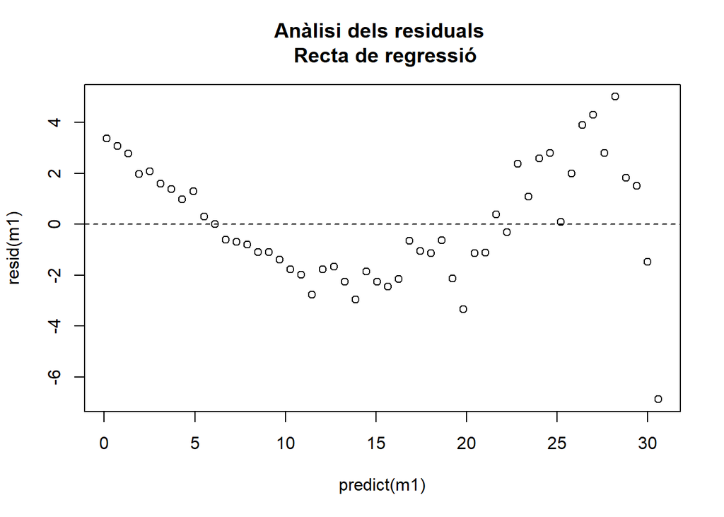

```r
plot(predict(m1),resid(m1),main="Anàlisi dels residuals \n Recta de regressió")
abline(h=0,lty=2)
```

**3. Dibuixeu la funció de regressió amb els punts observats, i la banda $predits\pm2\cdot\sigma$.**

```r
pm1<-predict(m1,interval="prediction")
```

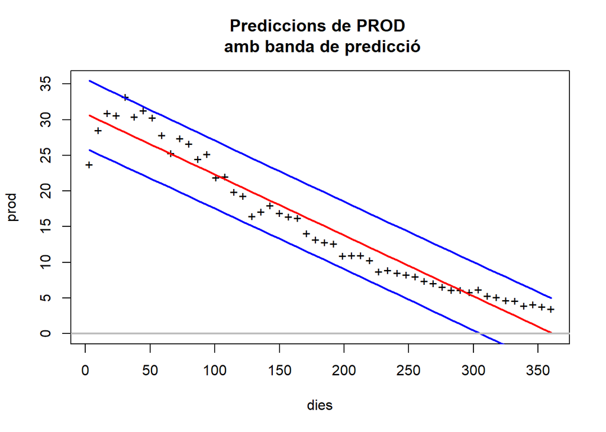

```r
plot(dd$DIES,dd$PROD,main="Prediccions de PROD \n amb banda de predicció",xlab="dies",ylab="prod",pch="+",ylim=c(0,max(pm1)))
lines(dd$DIES,predict(m1),col="red",lwd=2)
lines(dd$DIES,pm1[,"lwr"],col="blue",lwd=2)
lines(dd$DIES,pm1[,"upr"],col="blue",lwd=2)
abline(h=0,lwd=2,col="gray")
```

**4. Justifiqueu si us sembla que el model és adequat o no.**

#___________________________________________________________________________________________________________________

### b) Amb el model de la paràbola

$E[prod]=\beta_{0}+\beta_{1}dies+\beta_{2}dies^{2} :$

#### Ajusteu el model

**1. Trobeu la funció de regressió, plantegeu i contrasteu el test de cadascun dels paràmetres i estimeu-ne la variància de l’Error.**

```r
dd$DIES2<-dd$DIES^2
m2<-lm(PROD~DIES+DIES2,dd)
summary(m2)
```

```
##
## Call:
## lm(formula = PROD ~ DIES + DIES2, data = dd)
##
## Residuals:
##     Min      1Q  Median      3Q     Max
## -9.5024 -0.5554 -0.0463  0.7439  3.5465
##
## Coefficients:
##               Estimate Std. Error t value Pr(>|t|)
## (Intercept)  3.359e+01  8.192e-01  41.009  < 2e-16 ***
## DIES        -1.310e-01  1.043e-02 -12.566  < 2e-16 ***
## DIES2        1.260e-04  2.781e-05   4.532 3.76e-05 ***
## ---
## Signif. codes:  0 '***' 0.001 '**' 0.01 '*' 0.05 '.' 0.1 ' ' 1
##
## Residual standard error: 1.979 on 49 degrees of freedom
## Multiple R-squared:  0.9569, Adjusted R-squared:  0.9551
## F-statistic: 543.3 on 2 and 49 DF,  p-value: < 2.2e-16
```

```r
sm2<-summary(m2)$sigma
c("S"=sm2,"var"=sm2^2)
```

```
##        S      var
## 1.978634 3.914994
```

**2. Feu l’anàlisi del residus**

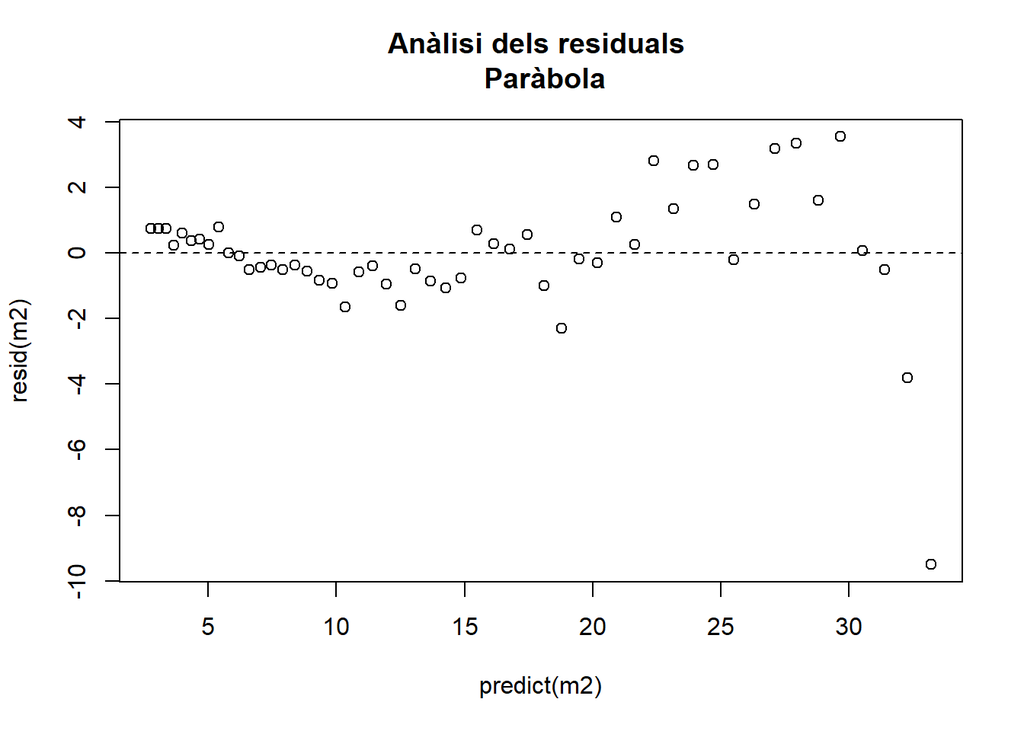

```r
plot(predict(m2),resid(m2),main="Anàlisi dels residuals \n Paràbola")
abline(h=0,lty=2)
```

**3. Dibuixeu la funció de regressió amb els punts observats, i la banda de predicció**

```r
pm2<-predict(m2,interval="prediction")
```

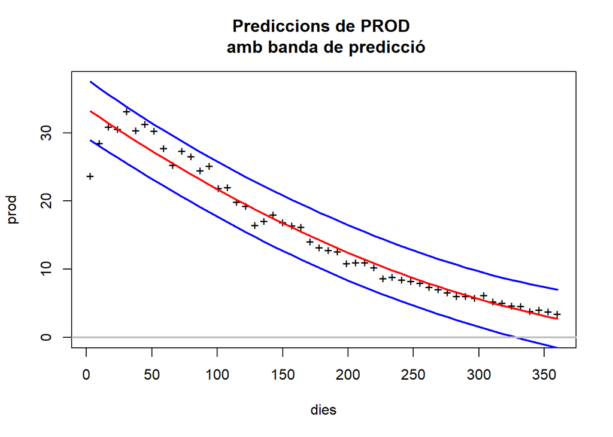

```r
plot(dd$DIES,dd$PROD,main="Prediccions de PROD \n amb banda de predicció",xlab="dies",ylab="prod",pch="+",ylim=c(0,max(pm2)))
lines(dd$DIES,predict(m2),col="red",lwd=2)
lines(dd$DIES,pm2[,"lwr"],col="blue",lwd=2)
lines(dd$DIES,pm2[,"upr"],col="blue",lwd=2)
abline(h=0,lwd=2,col="gray")
```

**4. Justifiqueu si us sembla que el model és adequat o no.**

#___________________________________________________________________________________________________________________

### c) Amb el model del polinomi de 3r grau

#### Ajusteu el model

**1. Trobeu la funció de regressió, plantegeu i contrasteu el test de cadascun dels paràmetres i estimeu-ne la variància de l’Error.**

```r
dd$DIES3<-dd$DIES^3
m3<-lm(PROD~DIES+DIES2+DIES3,dd)
summary(m3)
```

```
##
## Call:
## lm(formula = PROD ~ DIES + DIES2 + DIES3, data = dd)
##
## Residuals:
##     Min      1Q  Median      3Q     Max
## -7.1410 -0.8265  0.2123  0.8040  4.0097
##
## Coefficients:
##               Estimate Std. Error t value Pr(>|t|)
## (Intercept)  3.098e+01  9.384e-01  33.011  < 2e-16 ***
## DIES        -4.401e-02  2.243e-02  -1.962 0.055549 .
## DIES2       -4.740e-04  1.437e-04  -3.299 0.001835 **
## DIES3        1.102e-06  2.602e-07   4.235 0.000103 ***
## ---
## Signif. codes:  0 '***' 0.001 '**' 0.01 '*' 0.05 '.' 0.1 ' ' 1
##
## Residual standard error: 1.706 on 48 degrees of freedom
## Multiple R-squared:  0.9686, Adjusted R-squared:  0.9666
## F-statistic: 493.4 on 3 and 48 DF,  p-value: < 2.2e-16
```

```r
sm3<-summary(m3)$sigma
c("S"=sm3,"var"=sm3^2)
```

```
##        S      var
## 1.705689 2.909375
```

**2. Feu l’anàlisi del residus**

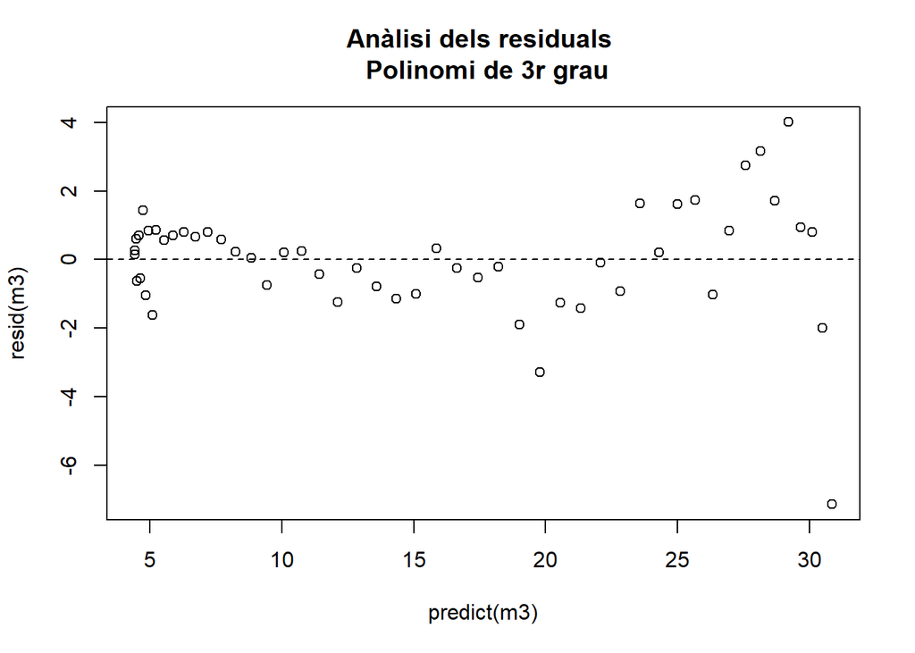

```r
plot(predict(m3),resid(m3),main="Anàlisi dels residuals \n Polinomi de 3r grau")
abline(h=0,lty=2)
```

**3. Dibuixeu la funció de regressió amb els punts observats, i la banda de predicció**

```r
pm3<-predict(m3,interval="prediction")
```

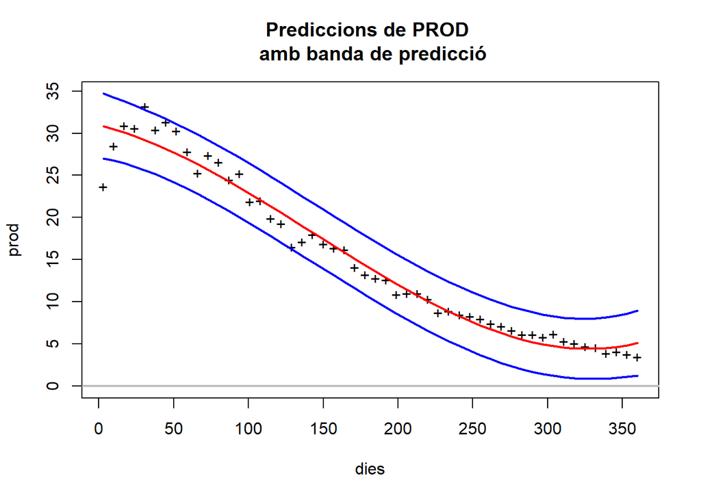

```r
plot(dd$DIES,dd$PROD,main="Prediccions de PROD \n amb banda de predicció",xlab="dies",ylab="prod",pch="+",ylim=c(0,max(pm3)))
lines(dd$DIES,predict(m3),col="red",lwd=2)
lines(dd$DIES,pm3[,"lwr"],col="blue",lwd=2)
lines(dd$DIES,pm3[,"upr"],col="blue",lwd=2)
abline(h=0,lwd=2,col="gray")
```

**4. Justifiqueu si us sembla que el model és adequat o no.**

#___________________________________________________________________________________________________________________

## d) Amb el Model lineal amb transformació log,

#### $E\left[\log\left(prod\right)\right]=\beta_{0}+\beta_{1}dies+\beta_{2}\log\left(dies\right)$ :

#### Ajusteu el model i

**1. Trobeu la funció de regressió, plantegeu i contrasteu el test ANOVA i estimeu-ne la variància de l’Error.**

```r
ml<-lm(log(PROD)~DIES+log(DIES),dd)
summary(ml)
```

```
##
## Call:
## lm(formula = log(PROD) ~ DIES + log(DIES), data = dd)
##
## Residuals:
##       Min        1Q    Median        3Q       Max
## -0.134840 -0.022413  0.002517  0.029435  0.125423
##
## Coefficients:
##               Estimate Std. Error t value Pr(>|t|)
## (Intercept)  2.9763226  0.0491626   60.54   <2e-16 ***
## DIES        -0.0080945  0.0001302  -62.15   <2e-16 ***
## log(DIES)    0.2070171  0.0139365   14.85   <2e-16 ***
## ---
## Signif. codes:  0 '***' 0.001 '**' 0.01 '*' 0.05 '.' 0.1 ' ' 1
##
## Residual standard error: 0.04686 on 49 degrees of freedom
## Multiple R-squared:  0.9955, Adjusted R-squared:  0.9953
## F-statistic:  5450 on 2 and 49 DF,  p-value: < 2.2e-16
```

```r
sl<-summary(ml)$sigma
c("S"=sl,"var"=sl^2)
```

```
##           S         var
## 0.046858902 0.002195757
```

**2. Dibuixeu la funció de regressió amb els punts, els residuals front els valors predits i la banda de predicció amb la funció de regressió i els punts observats.**

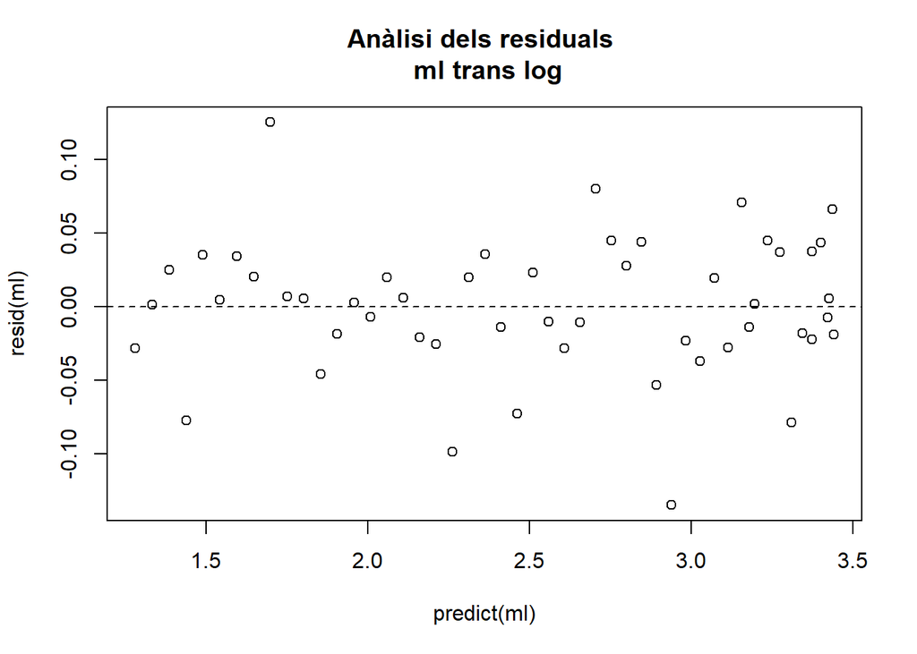

```r
plot(predict(ml),resid(ml),main="Anàlisi dels residuals \n ml trans log")
abline(h=0,lty=2)
```

**3. Dibuixeu la funció de regressió amb els punts observats i la banda de** $predicció_{\left(95\%\right)}$.

```r
prl<-predict(ml,interval="prediction",alpha=0.05)
```

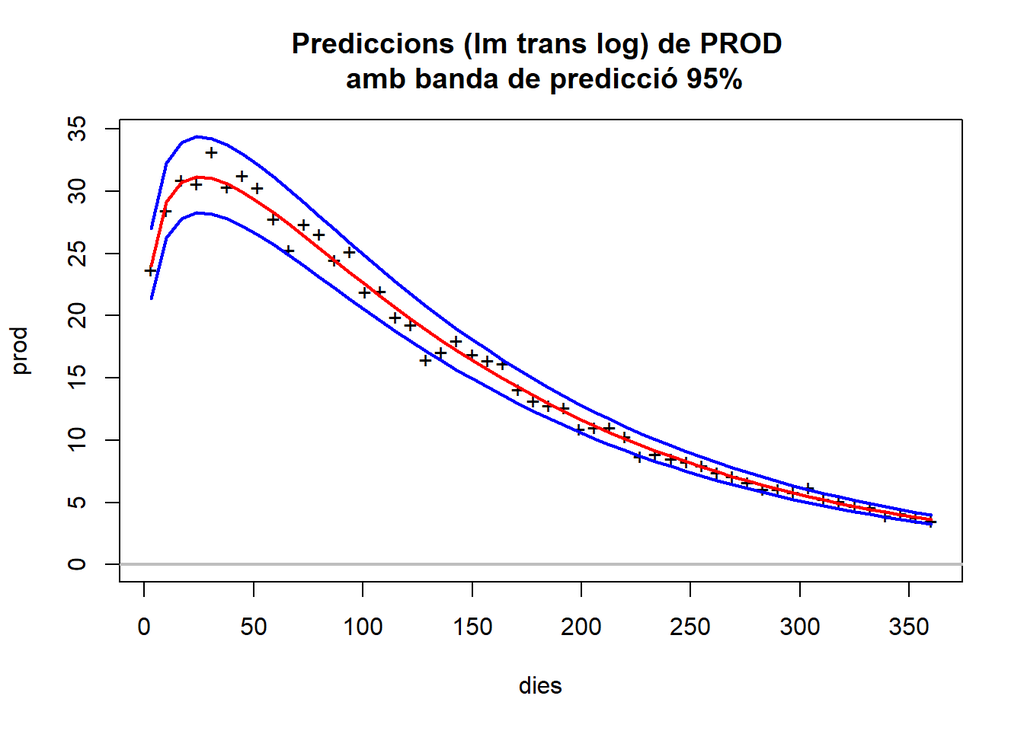

```r
plot(dd$DIES,dd$PROD,main="Prediccions (lm trans log) de PROD \n amb banda de predicció 95%",xlab="dies",ylab="prod",pch="+",ylim=c(0,exp(max(prl))))
lines(dd$DIES,exp(prl[,"fit"]),col="red",lwd=2)
lines(dd$DIES,exp(prl[,"lwr"]),col="blue",lwd=2)
lines(dd$DIES,exp(prl[,"upr"]),col="blue",lwd=2)
abline(h=0,lwd=2,col="gray")
```

**4. Justifiqueu si us sembla que el model és adequat o no.**

#___________________________________________________________________________________________________________________

### e) Entre tots els models d’aquest exercici, quin us sembla que és més adequat? per què?

*El ml de la funció Gamma transformada pel logaritme, sobretot per l’anàlisi dels residus, però també pels estadístics següents:*

```r
comp<-rbind("coef. det. aj."=
      c(summary(m1)$adj.r.squared,summary(m2)$adj.r.squared,summary(m3)$adj.r.squared,summary(ml)$adj.r.squared),
      "log versemblança"=
      c(logLik(m1),logLik(m2),logLik(m3),logLik(ml)),
      "AIC"=
      c(AIC(m1),AIC(m2),AIC(m3),AIC(ml)),
      "BIC"=
      c(BIC(m1),BIC(m2),BIC(m3),BIC(ml)))
colnames(comp)<-c("Recta","Prab.","P.3r.g","trans log")
print(comp)
```

```
##                         Recta        Prab.      P.3r.g    trans log
## coef. det. aj.      0.9375374    0.9550902   0.9666259    0.9953418
## log versemblança -116.8279642 -107.7249560 -99.4700851   86.9121478
## AIC               239.6559283  223.4499119 208.9401701 -165.8242955
## BIC               245.5096595  231.2548868 218.6963887 -158.0193206
```